# Estudio sobre el estado de funcionamiento de unas bombas de agua

Hassan Chafi Xavier

2/4/2022

## - Objetivo

En el presente proyecto se estudia un conjunto que contiene datos sobre unas bombas de agua y se realiza un modelo sobre la variable **status_group** que revelerá el estado (funcionamiento, no funcionamiento o necesidad de reparación) de las bombas de agua.

```r
#Carga de librerías
library(data.table)
library(dplyr)
library(caret)
library(scales)
library(ggplot2)
library(stringi)
library(stringr)
library(dataPreparation)
library(knitr)
library(kableExtra)
library(ggpubr)
library(tictoc)
library(ggeasy)
library(lubridate)
library(inspectdf)
library(ranger)
library(MLmetrics)
library(DataExplorer)
library(modeest)
```

## 1.Carga de datos

A continuación se comienza cargando el conjunto de datos que contiene los datos de entrenamiento así como el conjunto de datos que contiene los datos relativos a la variable objetivo **status_group** que releva el estado de las bombas de aguas.

```r
#Carga de datos
trainingV <- read.csv("TrainingSetValues.csv")
trainingL <- read.csv("TrainingSetLabels.csv")
```

Se concatenan los DataFrames cargados anteriormente para unir, en el conjunto de entrenamiento, las variables predictivas con la variable objetivo.

## 2.Exploración de datos

```r
#Concatenación del conjunto de entrenamiento y la variable objetivo
data <- merge(trainingV, trainingL, by = "id")
```

Se observa que algunas observaciones tienen algunas de sus variables con los campos vacíos, como por ejemplo la variable **public_meeting** en la primera observación o la variable **scheme_management** en la segunda observación.

```r
#Primeras observaciones del conjunto de train
head(data)
```

```
##   id amount_tsh date_recorded          funder gps_height installer longitude
## 1  0          0    2012-11-13           Tasaf          0     TASAF  33.12583
## 2  1          0    2011-03-05           Shipo       1978     SHIPO  34.77072
## 3  2          0    2011-03-27            Lvia          0      LVIA  36.11506
## 4  3         10    2013-06-03 Germany Republi       1639       CES  37.14743
## 5  4          0    2011-03-22            Cmsr          0      CMSR  36.16489
## 6  5         50    2011-02-26         Private         28   Private  39.28612
##    latitude       wpt_name num_private           basin subvillage      region
## 1 -5.118154        Mratibu           0 Lake Tanganyika    Majengo      Tabora
## 2 -9.395642           none           0          Rufiji   Magoda C      Iringa
## 3 -6.279268        Bombani           0     Wami / Ruvu Songambele      Dodoma
## 4 -3.187555 Area 7 Namba 5           0         Pangani    Urereni Kilimanjaro
## 5 -6.099289        Ezeleda           0     Wami / Ruvu    Maata A      Dodoma
## 6 -6.972403      Kwa Namaj           0     Wami / Ruvu   Mwandege       Pwani
##   region_code district_code      lga             ward population public_meeting
```

[output cut: 48 more lines]

Los campos vacíos anteriormente vistos, se considerarán como valores missings o valores perdidos; pasarán a tener el valor NA.

```r
#Los campos vacíos serán NA's
data[data == ""] <- NA
```

Se puede realizar una fase de exploración inicial del conjunto de los datos de entrenamiento en su totalidad para observar la frecuencia que tienen los valores dentro de las variables categóricas, la correlación entre las variables numéricas, los valores perdidos…

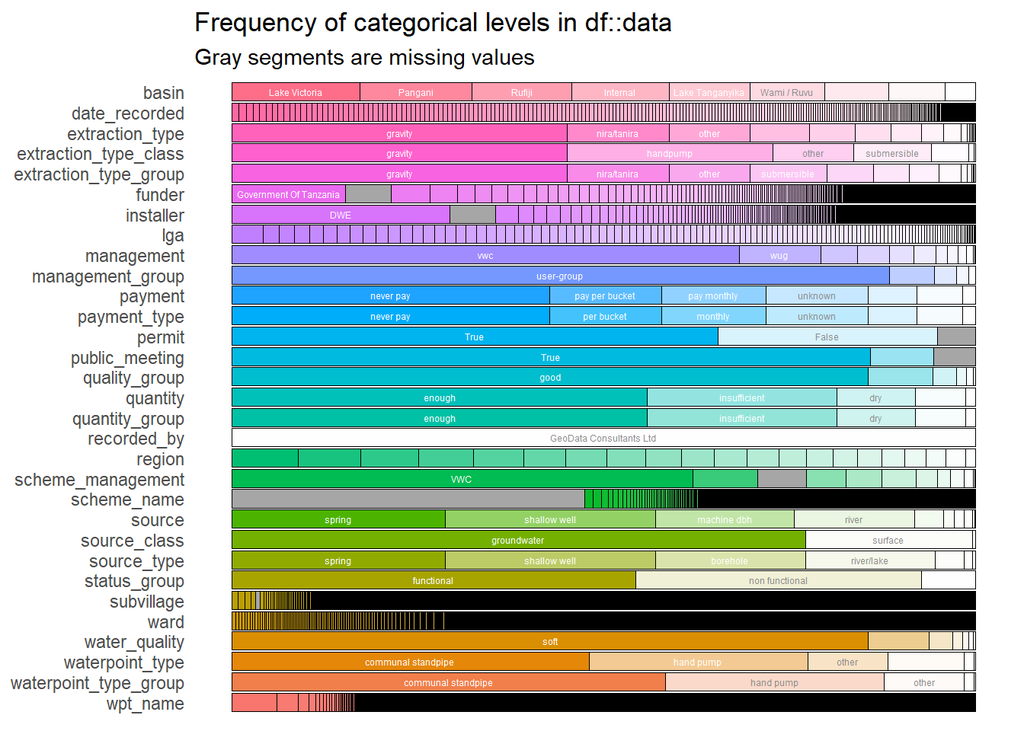

```r
#Exploración de los datos de train

# Frecuencia de variables categóricas
var_cat <- inspect_cat(data)
show_plot(var_cat)
```

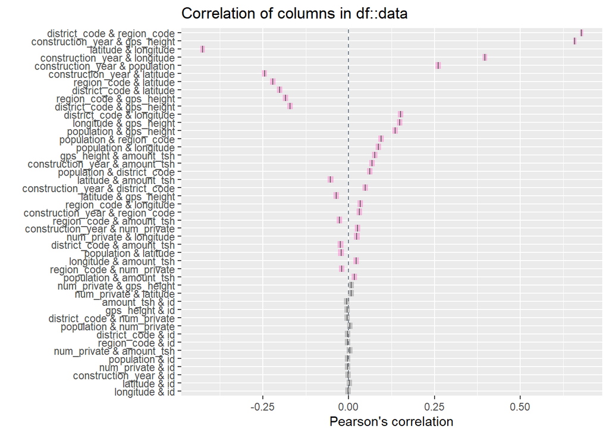

```r
# Correlación de variables numéricas
corr_num <- inspect_cor(data)
show_plot(corr_num)
```

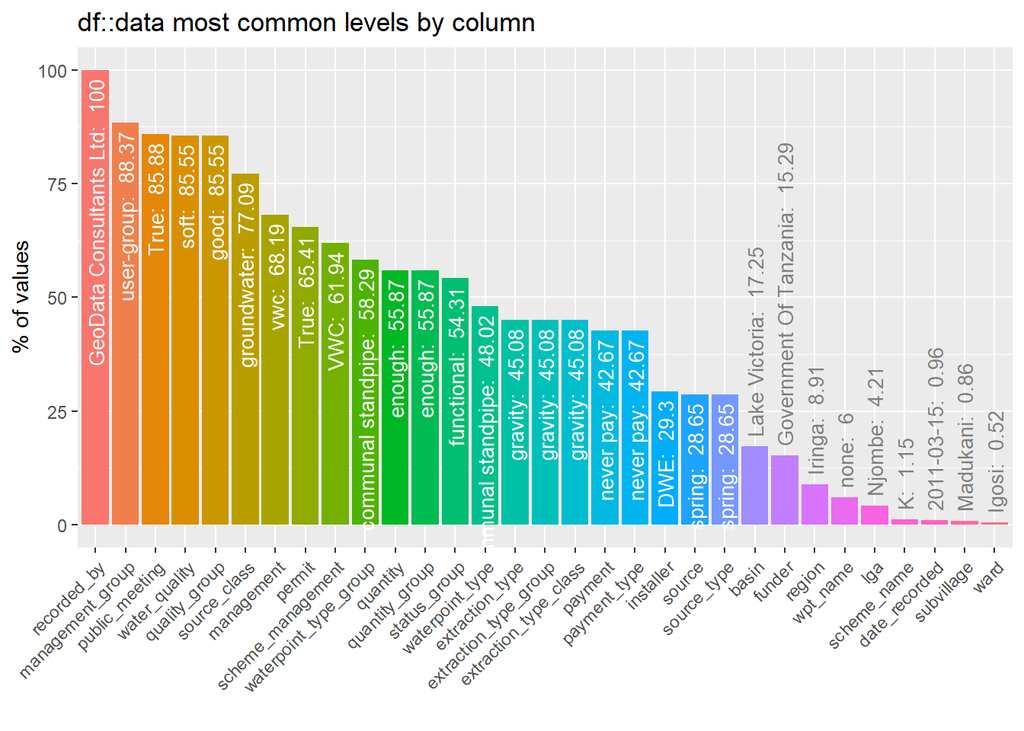

```r
# Porcentaje de frecuencia de valores en cariables categóricas
por_cat <- inspect_imb(data)
show_plot(por_cat)
```

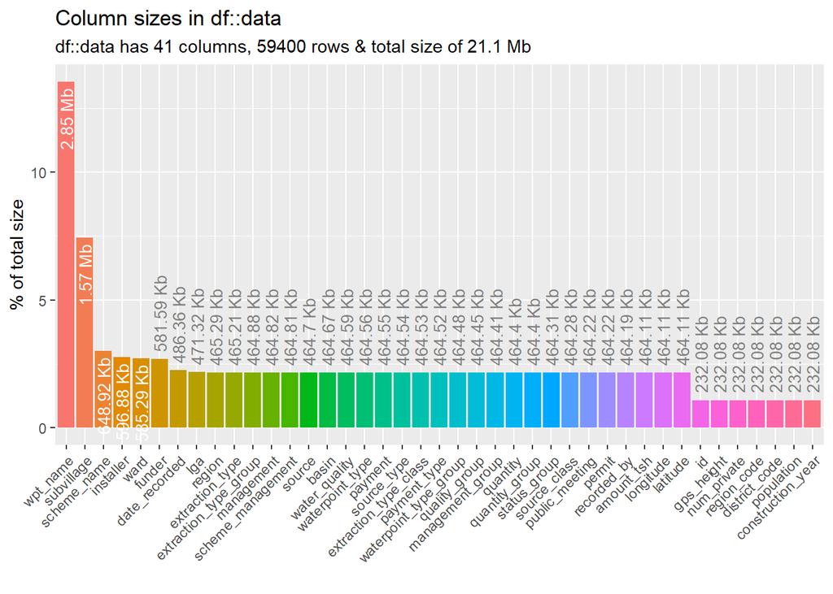

```r
# Uso de memoria
mem_var <- inspect_mem(data)
show_plot(mem_var)
```

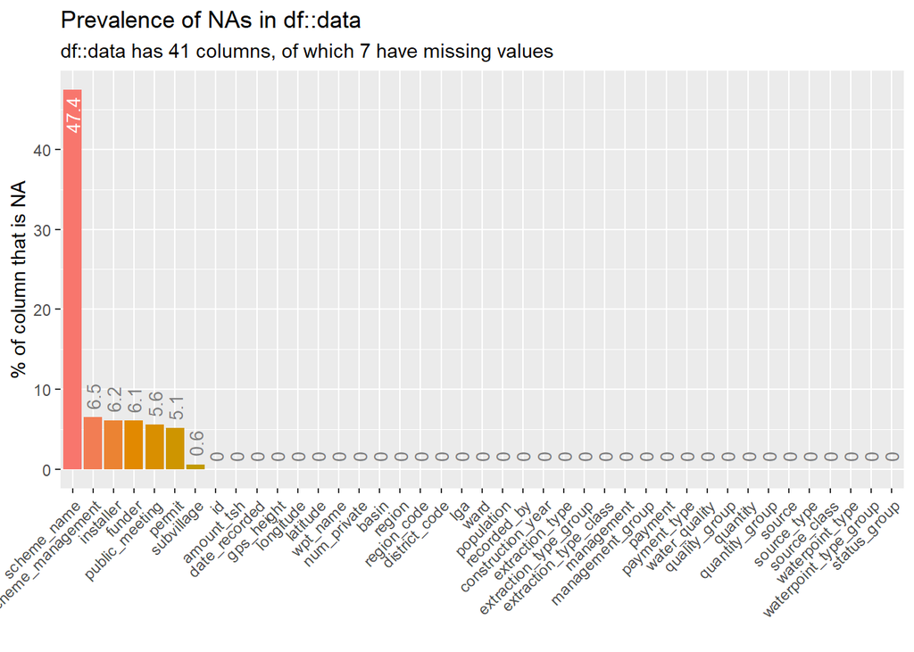

```r
# Valores perdidos
miss_var <- inspect_na(data)
show_plot(miss_var)
```

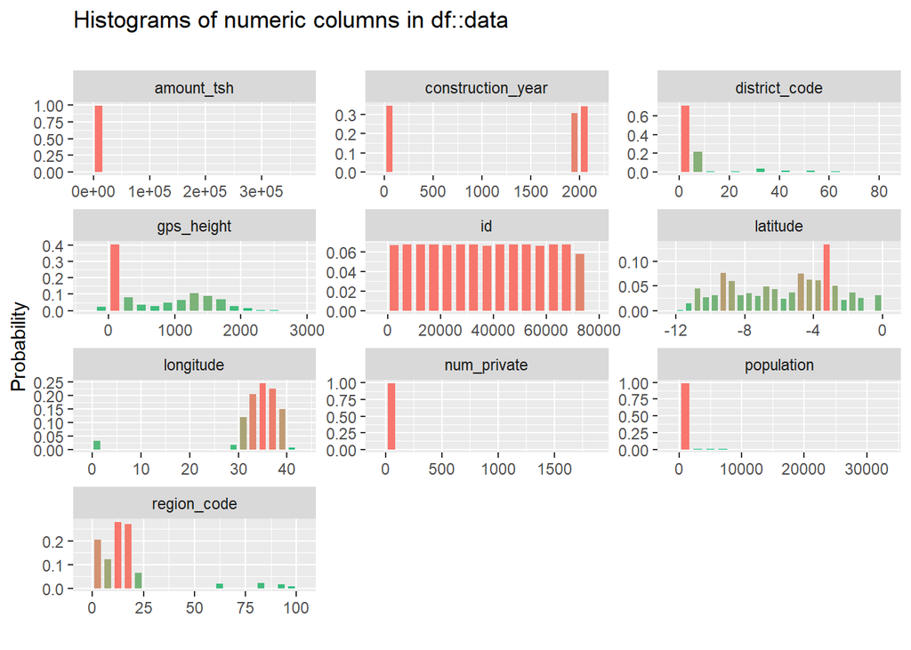

```r
# Histogramas de variables numéricas
hist_num <- inspect_num(data)
show_plot(hist_num)
```

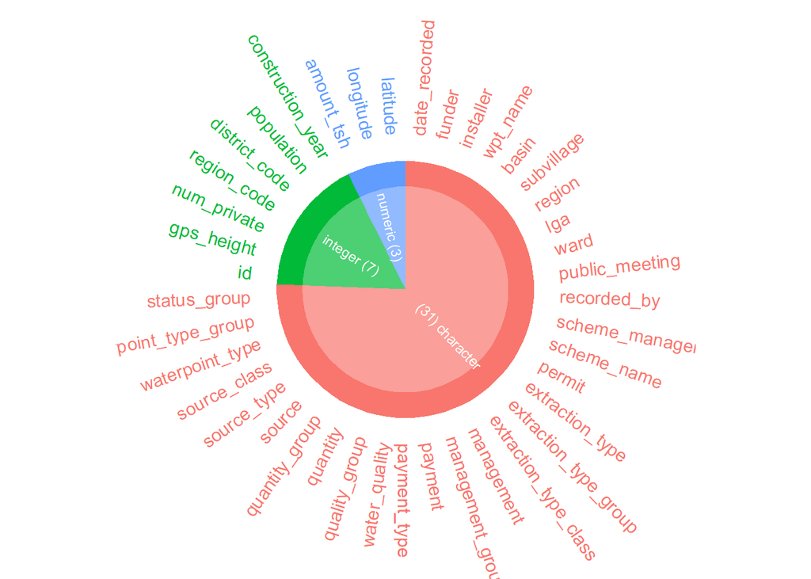

```r
# Tipo de variables
tip_var <- inspect_types(data)
show_plot(tip_var)
```

A continuación, se observa el porcentaje de aparición que tienen los distintos valores que puede adoptar la variable objetivo. Como se puede ver, no se trata de una variable binaria donde se tiene dos distintos valores; en este caso, se tienen hasta tres distintos posibles valores dentro de la variable objetivo.

```r
#Conocer el balanceo de la variable objetivo
round(prop.table(table(data$status_group)) * 100, 2)
```

```
##
##              functional functional needs repair          non functional
##                   54.31                    7.27                   38.42
```

Con el objetivo de tener un primer modelo que sirva de base para mejorarlo posteriormente mediante la adicción de más variables y realizando técnicas de feature engineering; se trabajará sobre un conjunto de entrenamiento que únicamente contengan las variables numéricas.

```r
#Copia del DataFrame de train seleccionando únicamente las numéricas
dataNum <- copy(data)
dataNum <- data %>% select_if(is.numeric)
dataNum$status_group <- data$status_group

#Paso a tipo factor la variable objetivo y elimino la variable id ya que no aporta valor al modelado
dataNum$status_group <- as.factor(dataNum$status_group)
dataNum$id <- NULL
```

Con la ayuda de la libreria de **DataExplorer** se puede realizar una exploración de los datos de este conjunto de variables numéricas creado para construir unas bases sobre las que mejorar el modelo predictivo.

```r
#Exploración del conjunto de datos de variables numéricas
plot_str(dataNum) #Estructura de las variables
introduce(dataNum) #Información básica del conjunto de datos
```

```
##    rows columns discrete_columns continuous_columns all_missing_columns
## 1 59400      10                1                  9                   0
##   total_missing_values complete_rows total_observations memory_usage
## 1                    0         59400             594000      3092568
```

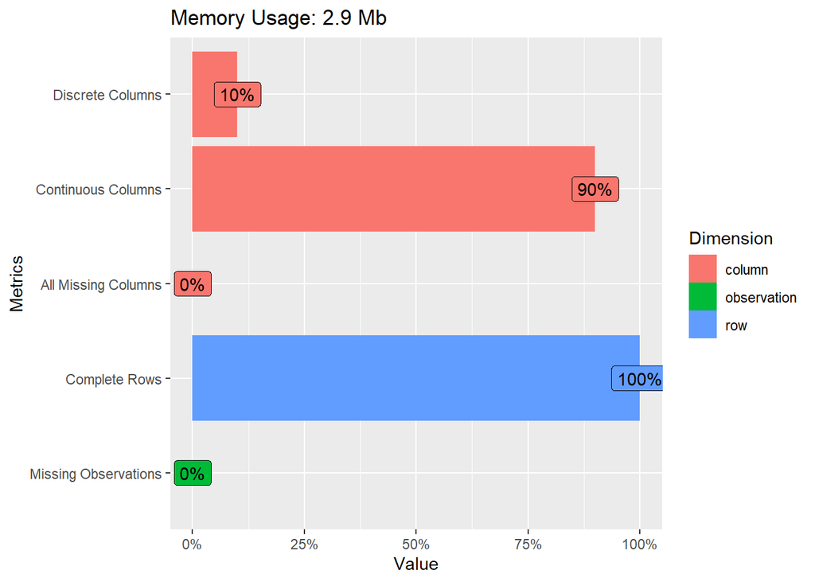

```r
plot_intro(dataNum) #Estado de los datos
```

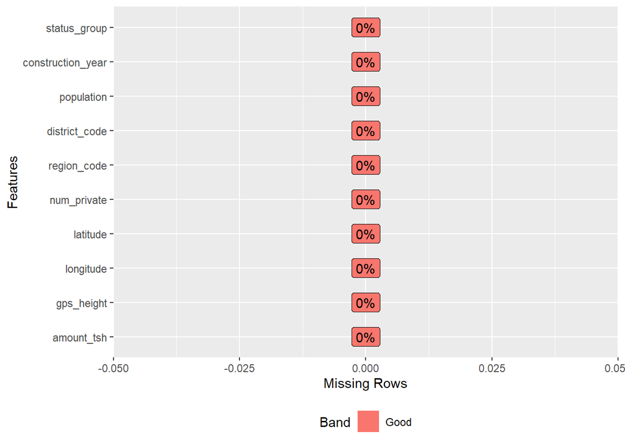

```r
plot_missing(dataNum) #Valores perdidos en los datos
```

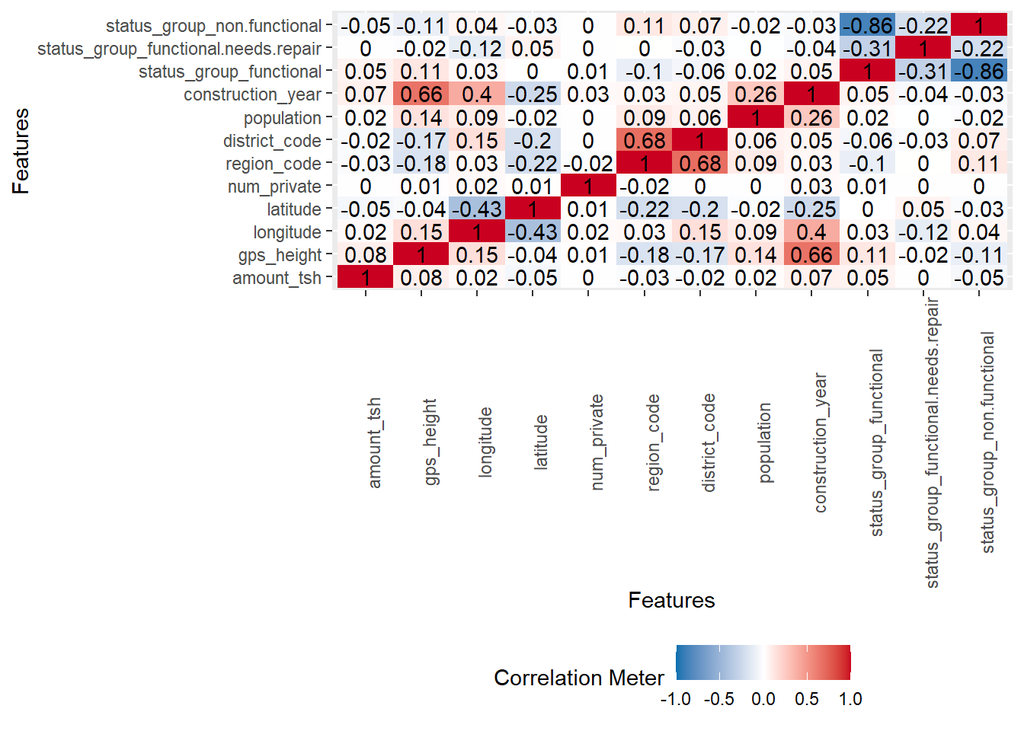

```r
plot_correlation(dataNum) #Correlación entre las variables
```

### Partición train-test

Uno de los pasos previos a la fase de modelado, es la partición del conjunto de datos en dos subconjuntos: uno de entrenamiento con el que se obtendrán los distintos modelos y otro de test con el que se evaluarán los modelos. El 80% de las observaciones del conjunto de datos será para entrenar los modelos y el 20% será para la evaluación de los modelos.

```r
#Partición entrenamiento-test
set.seed(123)
validationIndex <- createDataPartition(dataNum$status_group, p = 0.8, list = FALSE)

my_test  <- dataNum[-validationIndex,]
my_train <- dataNum[validationIndex,]
```

### Modelo lineal

Dado que la variable objetivo que se tiene (**status_group**) es una variable que tiene más de dos valores distintos (no es una variable dicotómica); el primer modelo que se entrenará será un modelo lineal, concretamente una regresión logística multinomial que ayuda a generalizar el método de regresión logística a problemas multiclase como en el que nos encontramos dadas las posibles situación de funcionamiento de las bombas de agua.

```r
#Construcción del modelo
trainControl <- trainControl(
                             method="cv",
                             number=3,
                             classProbs=TRUE,
                             summaryFunction=defaultSummary
                            )
set.seed(123)
fitMulti <- train(
             make.names(status_group)~.,
             data = my_train,
             method="multinom",
             metric="ROC",
             trControl=trainControl
            )
```

Al observar los resultados del modelo, ya se puede entrever que no será un modelo que se ajuste bien ya que el valor del Accuracy es próximo a 0.5, un valor que se traduce en una escasa capacidad del modelo a la hora de clasificar correctamente; asimismo, el valor Kappa (alrededor de 0.05) es muy pobre (un valor Kappa muy bueno sería a partir de 0.8).

```r
#Resultados del modelo
print(fitMulti)
```

```
## Penalized Multinomial Regression
##
## 47522 samples
##     9 predictor
##     3 classes: 'functional', 'functional.needs.repair', 'non.functional'
##
## No pre-processing
## Resampling: Cross-Validated (3 fold)
## Summary of sample sizes: 31682, 31681, 31681
## Resampling results across tuning parameters:
##
##   decay  Accuracy   Kappa
##   0e+00  0.5569631  0.04967705
##   1e-04  0.5569631  0.04967705
##   1e-01  0.5569631  0.04967705
##
## Accuracy was used to select the optimal model using the largest value.
## The final value used for the model was decay = 0.1.
```

```r
#Resultados del modelo
summary(fitMulti)
```

```
## Call:
## nnet::multinom(formula = .outcome ~ ., data = dat, decay = param$decay)
##
## Coefficients:
##                         (Intercept)    amount_tsh    gps_height    longitude
## functional.needs.repair  -0.7395472 -2.831298e-05 -0.0001344408 -0.038582124
## non.functional           -0.5194283 -2.971983e-04 -0.0003245920  0.005414184
##                             latitude   num_private region_code district_code
## functional.needs.repair  0.004959547 -0.0005200495  0.01151605  -0.016089509
## non.functional          -0.001022049 -0.0021566863  0.01244830  -0.007880621
##                            population construction_year
## functional.needs.repair  1.667959e-05      3.315279e-05
## non.functional          -1.124132e-04      1.004275e-04
##
## Std. Errors:
##                          (Intercept)   amount_tsh   gps_height    longitude
## functional.needs.repair 9.764665e-05 1.364635e-05 3.856965e-05 0.0014987997
## non.functional          3.795360e-05 1.759278e-05 2.002860e-05 0.0007885041
##                            latitude num_private  region_code district_code
## functional.needs.repair 0.007255103 0.002514412 0.0014409967   0.002944960
## non.functional          0.003872423 0.001481910 0.0007829815   0.001404165
##                           population construction_year
## functional.needs.repair 3.603586e-05      2.984338e-05
## non.functional          2.365242e-05      1.525629e-05
##
## Residual Deviance: 82535.64
## AIC: 82575.64
```

Ya en la matriz de confusión se puede observar que el modelo es incapaz de reconocer bombas de agua cuyo valor en la variable objetivo **status_group** es igual a **functional needs repair**.

```r
#Evaluación del modelo
predictions <- predict(fitMulti, newdata = my_test)
table(my_test$status_group, predictions)
```

```
##                          predictions
##                           functional functional.needs.repair non.functional
##   functional                    6224                       0            227
##   functional needs repair        825                       0             38
##   non functional                4137                       0            427
```

```r
#Realizo las predicciones (modelo lineal)
testV <- read.csv("TestSetValues.csv")
testValues <- copy(testV)

pred <- predict(fitMulti, testValues)
id <- as.data.frame(testValues$id)
status_group <- as.data.frame(pred)
my_pred <- cbind(id, status_group)
colnames(my_pred) <- c("id", "status_group")
write.csv(my_pred, "Predict.csv", row.names = FALSE)
```

### Modelo no lineal

El siguiente modelo que se entrena es un modelo no lineal mediante la función **ranger** que se trata de una implementación rápida de random forest. Inicialmente se realiza con 100 árboles, pero posteriormente se verán métodos para optimizar el número de árboles con el objetivo de mejorar los resultados del modelo.

```r
#Construcción del modelo
fitR <- ranger(
              status_group ~. ,
              data = my_train,
              num.trees = 100,
              importance = 'impurity',
              write.forest = TRUE,
              min.node.size = 1,
              splitrule = "gini",
              verbose = TRUE,
              classification = TRUE
            )
```

A continuación, en los resultados del modelo se puede ver una previsión de error del 29,46%.

```r
#Resultados del modelo
print(fitR)
```

```
## Ranger result
##
## Call:
##  ranger(status_group ~ ., data = my_train, num.trees = 100, importance = "impurity",      write.forest = TRUE, min.node.size = 1, splitrule = "gini",      verbose = TRUE, classification = TRUE)
##
## Type:                             Classification
## Number of trees:                  100
## Sample size:                      47522
## Number of independent variables:  9
## Mtry:                             3
## Target node size:                 1
## Variable importance mode:         impurity
## Splitrule:                        gini
## OOB prediction error:             29.46 %
```

```r
#Resultados del modelo
summary(fitR)
```

```
##                           Length Class         Mode
## predictions               47522  factor        numeric
## num.trees                     1  -none-        numeric
## num.independent.variables     1  -none-        numeric
## mtry                          1  -none-        numeric
## min.node.size                 1  -none-        numeric
## variable.importance           9  -none-        numeric
## prediction.error              1  -none-        numeric
## forest                        9  ranger.forest list
## confusion.matrix              9  table         numeric
## splitrule                     1  -none-        character
## treetype                      1  -none-        character
## call                         10  -none-        call
## importance.mode               1  -none-        character
## num.samples                   1  -none-        numeric
## replace                       1  -none-        logical
```

Una vez evaluado el modelo, se obtiene un Accuracy del 0.707

```r
#Evaluación del modelo
valor_pred <- predict(fitR, data = my_test)
table(my_test$status_group, valor_pred$predictions)
```

```
##
##                           functional functional needs repair non functional
##   functional                    5468                     105            878
##   functional needs repair        522                     167            174
##   non functional                1770                      32           2762
```

```r
Accuracy(y_pred = valor_pred$predictions, y_true = my_test$status_group)
```

```
## [1] 0.7069372
```

Una vez obtenido distintos resultados para el conjunto de datos únicamente con las variables numéricas con distintos algorítmos; se procederá a continuación a incluir más variables en el conjunto de datos e, incluso, elimnar variables que no sean relevantes para la explicabilidad de la variable objetivo. Para ello, se entrenará el modelo con el algoritmo de la función **ranger** ya que es el algoritmo que mejores resultados ha proporcionado de las dos implementaciones anteriores.

Se observa a continuación la importancia de las variables en el modelo y se aprecia que la importancia de la variable **num_private** es muy baja, por lo que se podría eliminar del modelo.

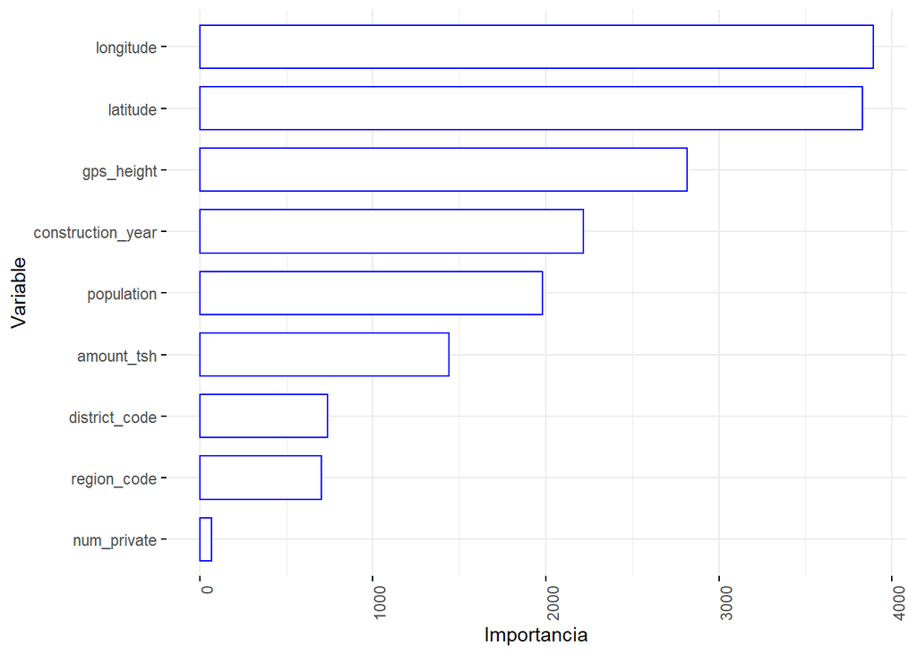

```r
# Importancia de las variables
vars_imp <- fitR$variable.importance
vars_imp <- as.data.frame(vars_imp)
vars_imp$myvar <- rownames(vars_imp)
vars_imp <- as.data.table(vars_imp)
setorder(vars_imp, -vars_imp)

ggbarplot(vars_imp[1:ncol(dataNum) - 1],
          x = "myvar", y = "vars_imp",
          color = "blue",
          palette = "jco",
          sort.val = "asc",
          sort.by.groups = FALSE,
          x.text.angle = 90,
          ylab = "Importancia",
          xlab = 'Variable',
          rotate = TRUE,
          ggtheme = theme_minimal()
          )
```

A continuación se incluirá en el modelo la variable **date_recorded**, para ello, previamente se comprueba si existenten valores perdidos en la variable.

```r
#Comprobación de NA´s en la variable
any(is.na(data$date_recorded))
```

```
## [1] FALSE
```

Como no existen valores perdidos en la variable, se procede a incluirla en el nuevo conjunto de datos donde se eliminarán las variables **id** ya que no aporta valor y la variable **num_private** que anteriormente se comprobó que tiene poca capacidad de influencia sobre la respuesta.

```r
#Construcción del nuevo conjunto de entrenamiento
data_1 <- cbind(select_if(data, is.numeric), date_recorder = data$date_recorded)
data_1$status_group <- as.factor(data$status_group)
data_1$id <- NULL
data_1$num_private <- NULL
```

Sobre la nueva variable incluida en el conjunto de entrenamiento se podría realizar una serie de modificaciones que den lugar a la creación de nuevas variables. También se puede crear una nueva variable llamada **distancia** a partir de las variables **longitud** y **latitud**.

```r
#Creación de nuevas variables
data_1$anyo    <- year(data_1$date_recorder)
data_1$mes     <- month(data_1$date_recorder)
data_1$dia     <- day(data_1$date_recorder)
data_1$distancia <- sqrt((data_1$longitude ^ 2) + (data_1$latitude ^ 2))

data_1$date_recorder <- NULL
```

```r
#Partición entrenamiento-test
set.seed(123)
validationIndex <- createDataPartition(data_1$status_group, p = 0.8, list = FALSE)

my_test  <- data_1[-validationIndex,]
my_train <- data_1[validationIndex,]
```

```r
#Construcción del modelo
fitR1 <- ranger(
              status_group ~. ,
              data = my_train,
              num.trees = 100,
              importance = 'impurity',
              write.forest = TRUE,
              min.node.size = 1,
              splitrule = "gini",
              verbose = TRUE,
              classification = TRUE
            )
```

Se observa una mejora respecto al conjunto de entrenamiento inicial ya que se pasa de un Accuracy de 0.707 a 0.727

```r
#Evaluación del modelo
valor_pred <- predict(fitR1, data = my_test)
table(my_test$status_group, valor_pred$predictions)
```

```
##
##                           functional functional needs repair non functional
##   functional                    5396                     108            947
##   functional needs repair        481                     190            192
##   non functional                1458                      54           3052
```

```r
Accuracy(y_pred = valor_pred$predictions, y_true = my_test$status_group)
```

```
## [1] 0.7272268
```

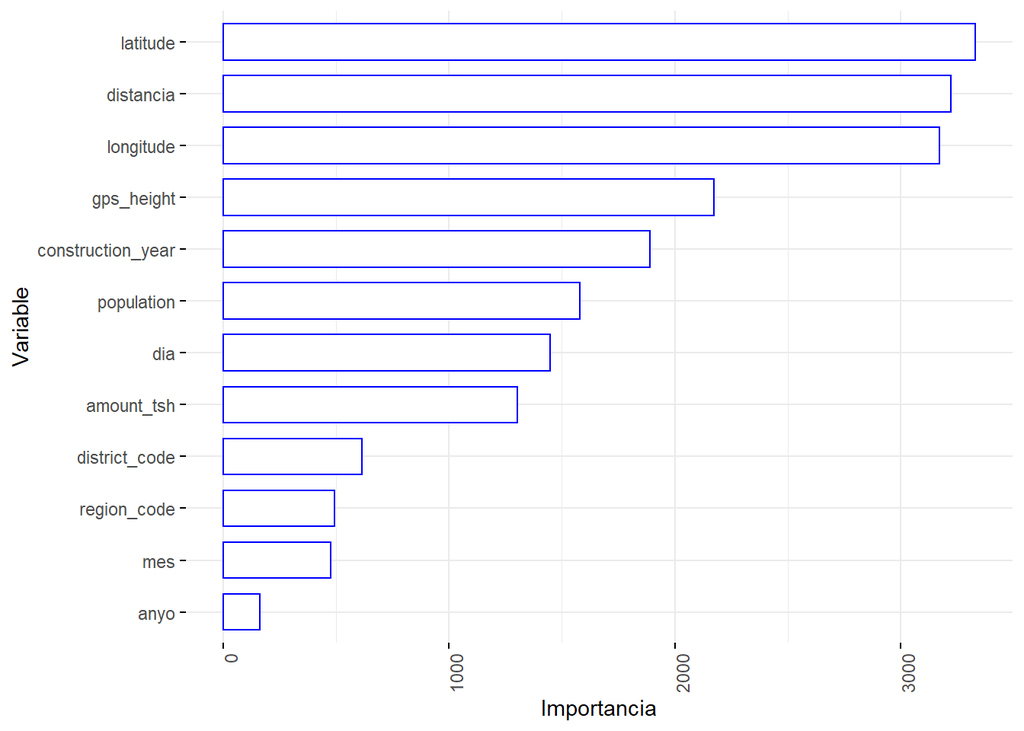

```r
# Importancia de las variables
vars_imp <- fitR1$variable.importance
vars_imp <- as.data.frame(vars_imp)
vars_imp$myvar <- rownames(vars_imp)
vars_imp <- as.data.table(vars_imp)
setorder(vars_imp, -vars_imp)

ggbarplot(vars_imp[1:ncol(data_1) - 1],
          x = "myvar", y = "vars_imp",
          color = "blue",
          palette = "jco",
          sort.val = "asc",
          sort.by.groups = FALSE,
          x.text.angle = 90,
          ylab = "Importancia",
          xlab = 'Variable',
          rotate = TRUE,
          ggtheme = theme_minimal()
          )
```

Como se ha visto anteriormente, la variable **anyo** es una variable que aporta poca influencia sobre la respuesta, por lo que se podría plantear su eliminación del conjunto de datos.

```r
#Construcción del nuevo conjunto de entrenamiento
data_2 <- copy(data_1)
data_2$anyo <- NULL
```

```r
#Partición entrenamiento-test
set.seed(123)
validationIndex <- createDataPartition(data_2$status_group, p = 0.8, list = FALSE)

my_test  <- data_2[-validationIndex,]
my_train <- data_2[validationIndex,]
```

```r
#Construcción del modelo
fitR2 <- ranger(
              status_group ~. ,
              data = my_train,
              num.trees = 100,
              importance = 'impurity',
              write.forest = TRUE,
              min.node.size = 1,
              splitrule = "gini",
              verbose = TRUE,
              classification = TRUE
            )
```

```r
#Evaluación del modelo
valor_pred <- predict(fitR2, data = my_test)
table(my_test$status_group, valor_pred$predictions)
```

```
##
##                           functional functional needs repair non functional
##   functional                    5386                     124            941
##   functional needs repair        476                     205            182
##   non functional                1461                      56           3047
```

```r
Accuracy(y_pred = valor_pred$predictions, y_true = my_test$status_group)
```

```
## [1] 0.7272268
```

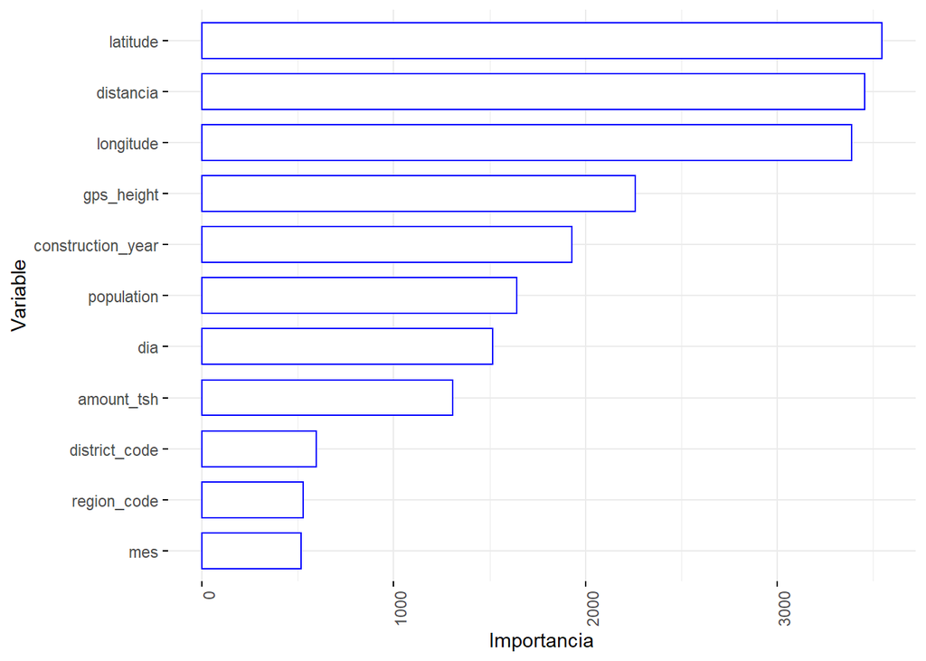

```r
# Importancia de las variables
vars_imp <- fitR2$variable.importance
vars_imp <- as.data.frame(vars_imp)
vars_imp$myvar <- rownames(vars_imp)
vars_imp <- as.data.table(vars_imp)
setorder(vars_imp, -vars_imp)

ggbarplot(vars_imp[1:ncol(data_2) - 1],
          x = "myvar", y = "vars_imp",
          color = "blue",
          palette = "jco",
          sort.val = "asc",
          sort.by.groups = FALSE,
          x.text.angle = 90,
          ylab = "Importancia",
          xlab = 'Variable',
          rotate = TRUE,
          ggtheme = theme_minimal()
          )
```

A continuación, se crea un nuevo conjunto de entrenamiento en el que se introducen las variables categóricas. Se observa que hay variables categóricas que tienen valores perdidos, por lo que es necesario la imputación de esos datos.

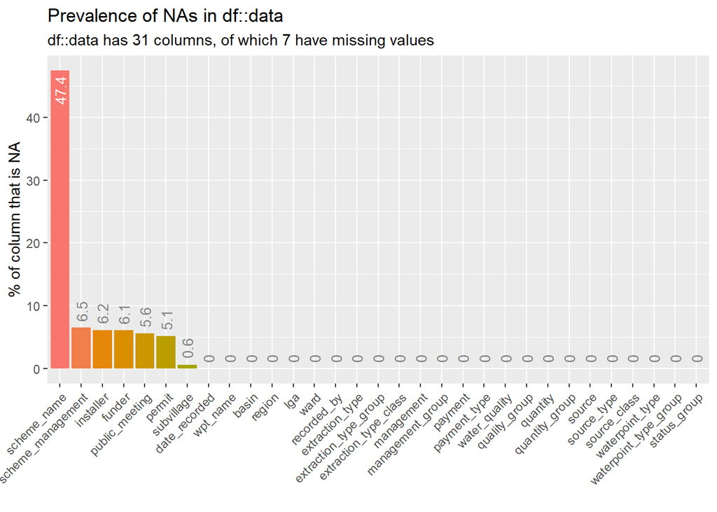

```r
#Missing en variables categóricas
miss_var_chr <- inspect_na(select_if(data, is.character))
show_plot(miss_var_chr)
```

Un método para imputar los valores NA´s en variables categóricas es mediante su moda. La variable que más valores NA´s tiene es **scheme_name** con un 47.4% de valores faltantes; esta situación junto con el hecho de que tiene hasta 2697 valores distintos, podría ser una buena razón para no considerar esta variable en el modelado.

```r
#Valores únicos de scheme_name
length(unique(data$scheme_name))
```

```
## [1] 2697
```

Posteriormente, se encuentran las variables **scheme_management**, **installer**, **funder**, **public_meeting**, **permit** y **subvillage** que tienen una proporción menor de NA’s por lo que se estudiará a continuación la imputación de sus valores faltantes.

```r
#Moda de la variable scheme_management
mlv(data$scheme_management)
```

```
## [1] "VWC"
```

```r
#Moda de la variable installer
mlv(data$installer)
```

```
## [1] "DWE"
```

```r
#Moda de la variable funder
mlv(data$funder)
```

```
## [1] "Government Of Tanzania"
```

```r
#Moda de la variable public_meeting
mlv(data$public_meeting)
```

```
## [1] "True"
```

```r
#Moda de la variable permit
mlv(data$permit)
```

```
## [1] "True"
```

```r
#Moda de la variable subvillage
mlv(data$subvillage)
```

```
## [1] NA
```

Se observa que la variable **subvillage** tiene como moda sus valores perdidos (NA’s), se consulta cuantos valores distintos tiene la variable y se obtiene que hasta 19288 valores; por lo que no se considerará tampoco para el modelado de datos.

```r
#Valores distintos de la variable subvillage
length(unique(data$subvillage))
```

```
## [1] 19288
```

```r
#Imputación de NA´s en la variable scheme_management
data$scheme_management[is.na(data$scheme_management)] <- "VWC"

#Imputación de NA´s en la variable installer
data$installer[is.na(data$installer)] <- "DWE"

#Imputación de NA´s en la variable funder
data$funder[is.na(data$funder)] <- "Government Of Tanzania"

#Imputación de NA´s en la variable public_meeting
data$public_meeting[is.na(data$public_meeting)] <- "True"

#Imputación de NA´s en la variable permit
data$permit[is.na(data$permit)] <- "True"
```

```r
#Construcción del conjunto de entrenamiento
dataChr <- select_if(data, is.character)
dataChr$status_group <- as.factor(dataChr$status_group)
#Eliminación de variables que no se considerarán en el modelado
dataChr$scheme_name <- NULL
dataChr$subvillage <- NULL
```

```r
#Partición entrenamiento-test
set.seed(123)
validationIndex <- createDataPartition(dataChr$status_group, p = 0.8, list = FALSE)

my_test  <- dataChr[-validationIndex,]
my_train <- dataChr[validationIndex,]
```

```r
#Construcción del modelo
fitR3 <- ranger(
              status_group ~. ,
              data = my_train,
              num.trees = 100,
              importance = 'impurity',
              write.forest = TRUE,
              min.node.size = 1,
              splitrule = "gini",
              verbose = TRUE,
              classification = TRUE
            )
```

Tal como se puede apreciar, este modelo únicamente con las variables categóricas obtiene un valor de Accuracy del 0.770

```r
#Evaluación del modelo
valor_pred <- predict(fitR3, data = my_test)
table(my_test$status_group, valor_pred$predictions)
```

```
##
##                           functional functional needs repair non functional
##   functional                    5891                      45            515
##   functional needs repair        616                     122            125
##   non functional                1399                      33           3132
```

```r
Accuracy(y_pred = valor_pred$predictions, y_true = my_test$status_group)
```

```
## [1] 0.7699108
```

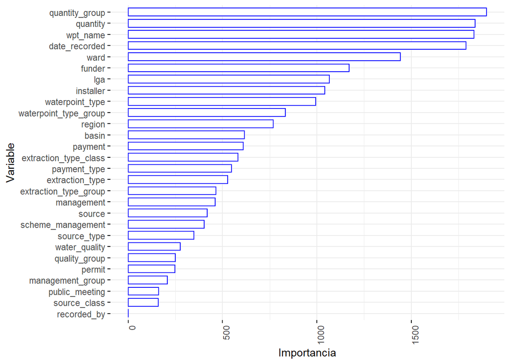

```r
# Importancia de las variables
vars_imp <- fitR3$variable.importance
vars_imp <- as.data.frame(vars_imp)
vars_imp$myvar <- rownames(vars_imp)
vars_imp <- as.data.table(vars_imp)
setorder(vars_imp, -vars_imp)

ggbarplot(vars_imp[1:ncol(dataChr) - 1],
          x = "myvar", y = "vars_imp",
          color = "blue",
          palette = "jco",
          sort.val = "asc",
          sort.by.groups = FALSE,
          x.text.angle = 90,
          ylab = "Importancia",
          xlab = 'Variable',
          rotate = TRUE,
          ggtheme = theme_minimal()
          )
```

A continuación se eliminan las variables con escasa capacidad de influencia como se ha visto anteriormente con la variable **recorded_by**.

```r
#Construcción del conjunto de entrenamiento
data_4 <- copy(dataChr)
data_4$recorded_by <- NULL
```

```r
#Partición entrenamiento-test
set.seed(123)
validationIndex <- createDataPartition(data_4$status_group, p = 0.8, list = FALSE)

my_test  <- data_4[-validationIndex,]
my_train <- data_4[validationIndex,]
```

```r
#Construcción del modelo
fitR4 <- ranger(
              status_group ~. ,
              data = my_train,
              num.trees = 100,
              importance = 'impurity',
              write.forest = TRUE,
              min.node.size = 1,
              splitrule = "gini",
              verbose = TRUE,
              classification = TRUE
            )
```

La eliminación de la variable **recorded_by** ha supuesto una mejora del valor del Accuracy pasando del 0.770 al 0.772

```r
#Evaluación del modelo
valor_pred <- predict(fitR4, data = my_test)
table(my_test$status_group, valor_pred$predictions)
```

```
##
##                           functional functional needs repair non functional
##   functional                    5920                      41            490
##   functional needs repair        616                     130            117
##   non functional                1404                      37           3123
```

```r
Accuracy(y_pred = valor_pred$predictions, y_true = my_test$status_group)
```

```
## [1] 0.7722681
```

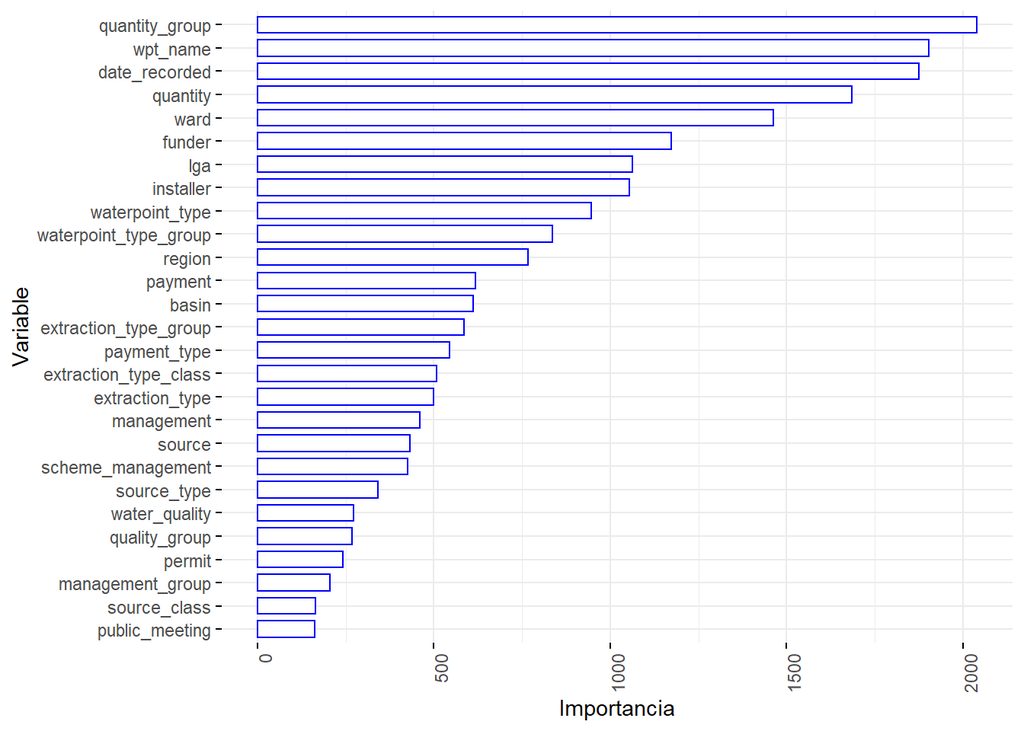

```r
# Importancia de las variables
vars_imp <- fitR4$variable.importance
vars_imp <- as.data.frame(vars_imp)
vars_imp$myvar <- rownames(vars_imp)
vars_imp <- as.data.table(vars_imp)
setorder(vars_imp, -vars_imp)

ggbarplot(vars_imp[1:ncol(data_4) - 1],
          x = "myvar", y = "vars_imp",
          color = "blue",
          palette = "jco",
          sort.val = "asc",
          sort.by.groups = FALSE,
          x.text.angle = 90,
          ylab = "Importancia",
          xlab = 'Variable',
          rotate = TRUE,
          ggtheme = theme_minimal()
          )
```

En este punto, se podría crear un nuevo conjunto con las variables numéricas ya tratadas y las variables categóricas ya tratadas.

```r
#Construcción del nuevo conjunto de entrenamiento con todas las variables
data_5 <- cbind(select_if(data_2, is.numeric), data_4) #Filtro en el primer conjunto para no obtener dos veces la variable objetivo
```

```r
#Partición entrenamiento-test
set.seed(123)
validationIndex <- createDataPartition(data_5$status_group, p = 0.8, list = FALSE)

my_test  <- data_5[-validationIndex,]
my_train <- data_5[validationIndex,]
```

```r
#Construcción del modelo
fitR5 <- ranger(
              status_group ~. ,
              data = my_train,
              num.trees = 100,
              importance = 'impurity',
              write.forest = TRUE,
              min.node.size = 1,
              splitrule = "gini",
              verbose = TRUE,
              classification = TRUE
            )
```

Se obtiene un valor de Accuracy del 0.806 que es un valor bastante bueno ya que se encuentra por encima de 0.8

```r
#Evaluación del modelo
valor_pred <- predict(fitR5, data = my_test)
table(my_test$status_group, valor_pred$predictions)
```

```
##
##                           functional functional needs repair non functional
##   functional                    5921                      74            456
##   functional needs repair        510                     228            125
##   non functional                1096                      40           3428
```

```r
Accuracy(y_pred = valor_pred$predictions, y_true = my_test$status_group)
```

```
## [1] 0.8062805
```

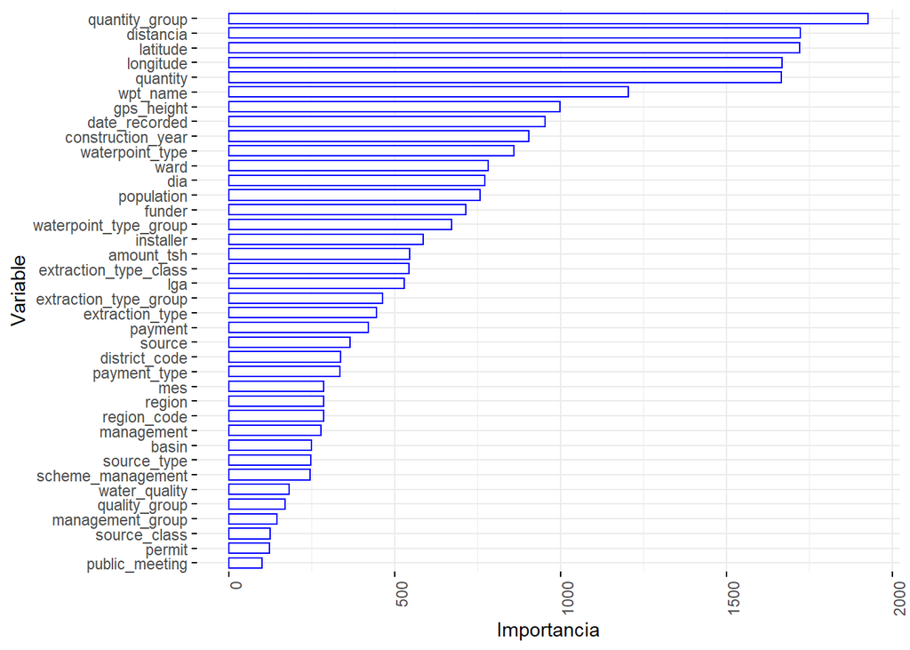

```r
# Importancia de las variables
vars_imp <- fitR5$variable.importance
vars_imp <- as.data.frame(vars_imp)
vars_imp$myvar <- rownames(vars_imp)
vars_imp <- as.data.table(vars_imp)
setorder(vars_imp, -vars_imp)

ggbarplot(vars_imp[1:ncol(data_5) - 1],
          x = "myvar", y = "vars_imp",
          color = "blue",
          palette = "jco",
          sort.val = "asc",
          sort.by.groups = FALSE,
          x.text.angle = 90,
          ylab = "Importancia",
          xlab = 'Variable',
          rotate = TRUE,
          ggtheme = theme_minimal()
          )
```

Al observar el conjunto de los datos, se observan variables que tienen nombres similares y que incluso adoptan los mismos valores. Se va a observar esta circunstancia mediantes tablas de contingencia.

```r
#Tabla de contingencia payment-payment_type
prop.table(table(data_5$payment, data_5$payment_type))
```

```
##
##                           annually    monthly  never pay on failure      other
##   never pay             0.00000000 0.00000000 0.42673401 0.00000000 0.00000000
##   other                 0.00000000 0.00000000 0.00000000 0.00000000 0.01774411
##   pay annually          0.06131313 0.00000000 0.00000000 0.00000000 0.00000000
##   pay monthly           0.00000000 0.13973064 0.00000000 0.00000000 0.00000000
##   pay per bucket        0.00000000 0.00000000 0.00000000 0.00000000 0.00000000
##   pay when scheme fails 0.00000000 0.00000000 0.00000000 0.06589226 0.00000000
##   unknown               0.00000000 0.00000000 0.00000000 0.00000000 0.00000000
##
##                         per bucket    unknown
##   never pay             0.00000000 0.00000000
##   other                 0.00000000 0.00000000
##   pay annually          0.00000000 0.00000000
##   pay monthly           0.00000000 0.00000000
##   pay per bucket        0.15126263 0.00000000
##   pay when scheme fails 0.00000000 0.00000000
##   unknown               0.00000000 0.13732323
```

```r
#Construcción del nuevo conjunto de entrenamiento
data_6 <- copy(data_5)
data_6$payment_type <- NULL
```

Se puede tramificar algunas variables numéricas con el objetivo de encontrar puntos de corte que revelen información relevante en la predicción de la variable objetivo. En este caso, se tramifican las variables **latitude** y **longitude**.

```r
#Tramificación de la variable latitude
tree_lat <- rpart::rpart(status_group ~ latitude, data = data_6, cp = 0.005)
tree_lat
```

```
## n= 59400
##
## node), split, n, loss, yval, (yprob)
##       * denotes terminal node
##
##  1) root 59400 27141 functional (0.54308081 0.07267677 0.38424242)
##    2) latitude>=-9.90583 54063 24090 functional (0.55440875 0.07352533 0.37206592)
##      4) latitude< -8.948985 6817  2282 functional (0.66524864 0.05222239 0.28252897) *
##      5) latitude>=-8.948985 47246 21808 functional (0.53841595 0.07659908 0.38498497)
##       10) latitude>=-4.8418 28232 12420 functional (0.56007368 0.08865826 0.35126806) *
##       11) latitude< -4.8418 19014  9388 functional (0.50625855 0.05869359 0.43504786)
##         22) latitude< -6.284119 12706  5760 functional (0.54667086 0.05997167 0.39335747) *
##         23) latitude>=-6.284119 6308  3034 non functional (0.42485732 0.05611921 0.51902346) *
##    3) latitude< -9.90583 5337  2628 non functional (0.42833052 0.06408094 0.50758853)
##      6) latitude< -10.93532 1154   553 functional (0.52079723 0.09792028 0.38128250) *
##      7) latitude>=-10.93532 4183  1914 non functional (0.40282094 0.05474540 0.54243366) *
```

```r
data_6$tree_lat <- factor(tree_lat$where)
levels(data_6$tree_lat) = c('(-8.948985)-(-10.93532)', '>=(-4.8418)', '(-6.284119)-(-8.948985)', '(-6.284119)-(-4.8418)','<(-10.93532)', '(-10.93532)-(-9.90583)')
```

```r
#Ordenación de los factores en la variable tree_lat
data_6$tree_lat <-factor(data_6$tree_lat, levels = c('(-8.948985)-(-10.93532)', '>=(-4.8418)', '(-6.284119)-(-8.948985)', '(-6.284119)-(-4.8418)','<(-10.93532)', '(-10.93532)-(-9.90583)'))
table(data_6$tree_lat)
```

```
##
## (-8.948985)-(-10.93532)             >=(-4.8418) (-6.284119)-(-8.948985)
##                    6817                   28232                   12706
##   (-6.284119)-(-4.8418)            <(-10.93532)  (-10.93532)-(-9.90583)
##                    6308                    1154                    4183
```

```r
#Tramificación de la variable longitude
tree_long <- rpart::rpart(status_group ~ longitude, data = data_6, cp = 0.005)
tree_long
```

```
## n= 59400
##
## node), split, n, loss, yval, (yprob)
##       * denotes terminal node
##
## 1) root 59400 27141 functional (0.54308081 0.07267677 0.38424242)
##   2) longitude< 37.50894 46866 20514 functional (0.56228396 0.07803098 0.35968506) *
##   3) longitude>=37.50894 12534  6567 non functional (0.47127812 0.05265677 0.47606510)
##     6) longitude< 38.50322 5427  2726 functional (0.49769670 0.07278423 0.42951907) *
##     7) longitude>=38.50322 7107  3471 non functional (0.45110454 0.03728718 0.51160827) *
```

```r
data_6$tree_long <- factor(tree_long$where)
levels(data_6$tree_long) = c('<37.50894','37.50894-38.50322', '>=38.50322')
```

```r
#Ordenación de los factores en la variable tree_long
data_6$tree_long <-factor(data_6$tree_long, levels = c('<37.50894','37.50894-38.50322', '>=38.50322'))
table(data_6$tree_long)
```

```
##
##         <37.50894 37.50894-38.50322        >=38.50322
##             46866              5427              7107
```

```r
#Partición entrenamiento-test
set.seed(123)
validationIndex <- createDataPartition(data_6$status_group, p = 0.8, list = FALSE)

my_test  <- data_6[-validationIndex,]
my_train <- data_6[validationIndex,]
```

```r
#Construcción del modelo
fitR6 <- ranger(
              status_group ~. ,
              data = my_train,
              num.trees = 100,
              importance = 'impurity',
              write.forest = TRUE,
              min.node.size = 1,
              splitrule = "gini",
              verbose = TRUE,
              classification = TRUE
            )
```

La eliminación de la variable **payment_type** y la tramificación de las variables supone un incremento del valor de Accuracy pasando del 0.8063 al 0.8081

```r
#Evaluación del modelo
valor_pred <- predict(fitR6, data = my_test)
table(my_test$status_group, valor_pred$predictions)
```

```
##
##                           functional functional needs repair non functional
##   functional                    5904                      84            463
##   functional needs repair        500                     239            124
##   non functional                1066                      42           3456
```

```r
Accuracy(y_pred = valor_pred$predictions, y_true = my_test$status_group)
```

```
## [1] 0.8081327
```

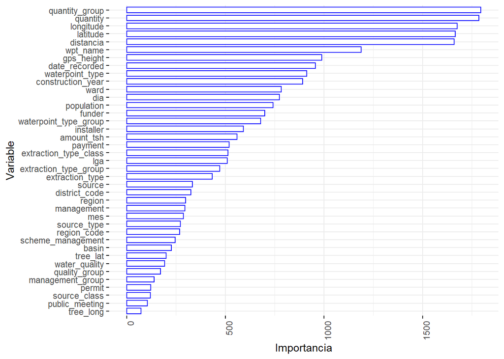

```r
# Importancia de las variables
vars_imp <- fitR6$variable.importance
vars_imp <- as.data.frame(vars_imp)
vars_imp$myvar <- rownames(vars_imp)
vars_imp <- as.data.table(vars_imp)
setorder(vars_imp, -vars_imp)

ggbarplot(vars_imp[1:ncol(data_6) - 1],
          x = "myvar", y = "vars_imp",
          color = "blue",
          palette = "jco",
          sort.val = "asc",
          sort.by.groups = FALSE,
          x.text.angle = 90,
          ylab = "Importancia",
          xlab = 'Variable',
          rotate = TRUE,
          ggtheme = theme_minimal()
          )
```

A continuación se crea una nueva versión donde se introduce una variable correspondiente con el día de la semana en función de la variable **date_recorded**.

```r
#Construcción del nuevo conjunto de entrenamiento
data_7 <- copy(data_5)
data_7$diasem  <- wday(data_7$date_recorded, label = TRUE, abbr = TRUE)
```

```r
#Partición entrenamiento-test
set.seed(123)
validationIndex <- createDataPartition(data_7$status_group, p = 0.8, list = FALSE)

my_test  <- data_7[-validationIndex,]
my_train <- data_7[validationIndex,]
```

```r
#Construcción del modelo
fitR7 <- ranger(
              status_group ~. ,
              data = my_train,
              num.trees = 100,
              importance = 'impurity',
              write.forest = TRUE,
              min.node.size = 1,
              splitrule = "gini",
              verbose = TRUE,
              classification = TRUE
            )
```

Se pasa de un valor de Accuracy del 0.8081 del anterior modelo a un valor de 0.8086

```r
#Evaluación del modelo
valor_pred <- predict(fitR7, data = my_test)
table(my_test$status_group, valor_pred$predictions)
```

```
##
##                           functional functional needs repair non functional
##   functional                    5895                      88            468
##   functional needs repair        481                     260            122
##   non functional                1069                      45           3450
```

```r
Accuracy(y_pred = valor_pred$predictions, y_true = my_test$status_group)
```

```
## [1] 0.8086378
```

A continuación, a partir del conjunto de entrenamiento anterior, se pone a prueba cuál es el número de árboles en la función de **ranger** que maximiza la capacidad predictiva.

```r
# Barrido con diferente número de arboles.
val_trees <- c(100, 150, 200, 250)

for (i in val_trees) {
  print(i)
  fitR8 <- ranger(
                  status_group ~. ,
                  data = my_train,
                  num.trees = i,
                  keep.inbag = TRUE,
                  importance = 'impurity',
                  write.forest = TRUE,
                  min.node.size = 1,
                  splitrule = "gini",
                  verbose = TRUE,
                  classification = TRUE,
                  set.seed(123)
                )

  valor_pred <- predict(fitR8, data = my_test)
  fit_acc <- Accuracy(y_pred = valor_pred$predictions, y_true = my_test$status_group)
  print(fit_acc)
}
```

```
## [1] 100
## [1] 0.8088062
## [1] 150
## [1] 0.810069
## [1] 200
## [1] 0.8115844
## [1] 250
## [1] 0.811837
```

```r
fitR7 <- ranger(
                  status_group ~. ,
                  data = my_train,
                  num.trees = 250,
                  importance = 'impurity',
                  write.forest = TRUE,
                  min.node.size = 1,
                  splitrule = "gini",
                  verbose = TRUE,
                  classification = TRUE,
                  set.seed(123),
                  #class.weights = c(0.5, 0.1, 0.4)
                )
```

Se entrena de nuevo el modelo, esta vez con un valor de 250 como número de árboles puesto que es con los que se obtiene mayor capacidad de predicción.

Se pasa de un valor de Accuracy de 0.8086 del modelo **R7** a un valor de 0.8118

```r
#Evaluación del modelo
valor_pred <- predict(fitR8, data = my_test)
table(my_test$status_group, valor_pred$predictions)
```

```
##
##                           functional functional needs repair non functional
##   functional                    5949                      74            428
##   functional needs repair        502                     245            116
##   non functional                1076                      39           3449
```

```r
Accuracy(y_pred = valor_pred$predictions, y_true = my_test$status_group)
```

```
## [1] 0.811837
```

```r
#Realizo las predicciones (modelo no lineal)
testV <- read.csv("TestSetValues.csv")
testValues <- copy(testV)

testValues <- cbind(select_if(testValues, is.numeric), date_recorder = testValues$date_recorded)
testValues$num_private <- NULL
testValues$anyo    <- year(testValues$date_recorder)
testValues$mes     <- month(testValues$date_recorder)
testValues$dia     <- day(testValues$date_recorder)
testValues$distancia <- sqrt((testValues$longitude ^ 2) + (testValues$latitude ^ 2))
testValues$date_recorded <- NULL


testChr <- copy(testV)
testChr <- select_if(testChr, is.character)
testChr[testChr == ""] <- NA
testChr$scheme_management[is.na(testChr$scheme_management)] <- "VWC"
testChr$installer[is.na(testChr$installer)] <- "DWE"
testChr$funder[is.na(testChr$funder)] <- "Government Of Tanzania"
testChr$public_meeting[is.na(testChr$public_meeting)] <- "True"
testChr$permit[is.na(testChr$permit)] <- "True"
testChr$scheme_name <- NULL
testChr$subvillage <- NULL
testChr$recorded_by <- NULL

testModel <- cbind(select_if(testValues, is.numeric), testChr)
testModel$diasem  <- wday(testModel$date_recorded, label = TRUE, abbr = TRUE)

pred <- predict(fitR8, testModel)
id <- as.data.frame(testValues$id)
status_group <- as.data.frame(pred$prediction)
my_pred <- cbind(id, status_group)
colnames(my_pred) <- c("id", "status_group")
write.csv(my_pred, "Predict.csv", row.names = FALSE)
```

### Mundo H2O

Se inicia el mundo h2o con el objetivo de utilizar alguno de sus algoritmos.

```r
#Creación del clúster
library(h2o)

h2o.init(nthreads = 4, max_mem_size = '2g') #CPU + Memoria
```

```
##
## H2O is not running yet, starting it now...
##
## Note:  In case of errors look at the following log files:
##     C:\Users\96has\AppData\Local\Temp\Rtmpg1y0hQ\file32cc66102510/h2o_96has_started_from_r.out
##     C:\Users\96has\AppData\Local\Temp\Rtmpg1y0hQ\file32cc300c4834/h2o_96has_started_from_r.err
##
##
## Starting H2O JVM and connecting:  Connection successful!
##
## R is connected to the H2O cluster:
##     H2O cluster uptime:         2 seconds 875 milliseconds
##     H2O cluster timezone:       Europe/Paris
##     H2O data parsing timezone:  UTC
##     H2O cluster version:        3.36.0.4
##     H2O cluster version age:    1 month and 2 days
##     H2O cluster name:           H2O_started_from_R_96has_ncj154
##     H2O cluster total nodes:    1
##     H2O cluster total memory:   1.76 GB
##     H2O cluster total cores:    8
##     H2O cluster allowed cores:  4
##     H2O cluster healthy:        TRUE
##     H2O Connection ip:          localhost
##     H2O Connection port:        54321
##     H2O Connection proxy:       NA
##     H2O Internal Security:      FALSE
##     R Version:                  R version 4.1.2 (2021-11-01)
```

```r
options("h2o.use.data.table" = TRUE)

dataNum_hex <- as.h2o(data)
splits <- h2o.splitFrame(
  data = dataNum_hex,
  ratios = c(0.6,0.2),
  destination_frames = c("train_hex", "valid_hex", "test_hex"),
  seed = 123
)
train_hex <- splits[[1]]
valid_hex <- splits[[2]]
test_hex  <- splits[[3]]
```

De los algoritmos de h2o, se hace uso de random forest.

```r
#Construcción del modelo con uno de los algorítmos de h2o
y <- "status_group"
x <- setdiff(names(dataNum_hex), y)
train_hex[, y] <- as.factor(train_hex[,y] )

nfolds <- 5

my_model <- h2o.randomForest(
  x = x,
  y = y,
  training_frame = train_hex,
  validation_frame = valid_hex,
  nfolds = nfolds,
  keep_cross_validation_predictions = TRUE,
  seed = 123,
  stopping_metric = 'AUC',
  verbose = FALSE,
  ntrees = 150,
  max_depth = 5,
)
```

Se obtiene un valor del Accuracy de 0.624 de media.

```r
#Resultados del modelo
my_model
```

```
## Model Details:
## ==============
##
## H2OMultinomialModel: drf
## Model ID:  DRF_model_R_1651510451771_1
## Model Summary:
##   number_of_trees number_of_internal_trees model_size_in_bytes min_depth
## 1             150                      450              193680         5
##   max_depth mean_depth min_leaves max_leaves mean_leaves
## 1         5    5.00000         16         32    29.53111
##
##
## H2OMultinomialMetrics: drf
## ** Reported on training data. **
## ** Metrics reported on Out-Of-Bag training samples **
##
## Training Set Metrics:
## =====================
##
## Extract training frame with `h2o.getFrame("RTMP_sid_9653_7")`
## MSE: (Extract with `h2o.mse`) 0.2842683
## RMSE: (Extract with `h2o.rmse`) 0.5331681
## Logloss: (Extract with `h2o.logloss`) 0.8033043
## Mean Per-Class Error: 0.5850705
## AUC: (Extract with `h2o.auc`) NaN
## AUCPR: (Extract with `h2o.aucpr`) NaN
## R^2: (Extract with `h2o.r2`) 0.6848461
## Confusion Matrix: Extract with `h2o.confusionMatrix(<model>,train = TRUE)`)
## =========================================================================
## Confusion Matrix: Row labels: Actual class; Column labels: Predicted class
##                         functional functional needs repair non functional
## functional                   17689                       0           1685
## functional needs repair       2100                       7            463
## non functional                9158                       4           4493
## Totals                       28947                      11           6641
##                          Error              Rate
## functional              0.0870 =  1.685 / 19.374
## functional needs repair 0.9973 =   2.563 / 2.570
## non functional          0.6710 =  9.162 / 13.655
## Totals                  0.3767 = 13.410 / 35.599
```

[output cut: 89 more lines]

```
## r2                         0.684782  0.001346    0.685364    0.683276
## rmse                       0.533199  0.001738    0.532834    0.535137
##                          cv_3_valid  cv_4_valid  cv_5_valid
## accuracy                   0.631951    0.625914    0.623521
## auc                              NA          NA          NA
## err                        0.368049    0.374086    0.376479
## err_count               2654.000000 2659.000000 2673.000000
## logloss                    0.797200    0.806445    0.803787
## max_per_class_error        0.994059    1.000000    0.998084
## mean_per_class_accuracy    0.419286    0.416729    0.415614
## mean_per_class_error       0.580714    0.583271    0.584386
## mse                        0.281405    0.285182    0.284646
## pr_auc                           NA          NA          NA
## r2                         0.686791    0.684162    0.684317
## rmse                       0.530477    0.534025    0.533522
```

```r
#Cierre del clúster
h2o.shutdown(prompt = FALSE)
```